# Lab Assignment One: Exploring Table Data

```
47491968 Yuankai Liu     47511663 Jianing Zhao     47564911 Yang Peng
```

## 1、Business Understanding

This dataset is from IGN website and it includes information of games released in past 20 years. It really attracts us. Nowadays, the gaming industy is in recession, so gaming companys should learn more about the trend and popular genres in this industry to help themselves develop and improve their games.

There are 10 features and 18625 objects in this dataset. We can use data visualization to have a intuitive result and then get some idea for future.

By visualizing the distributions for the subset of single attributes and the relationships between a subset of attributes,we can explore some specific questions:

Editor choice rate by genres.

Editors choice rate by release year.

Editors choice rate by popular platform.

Distribution of scores.

line chart of release and month.

Editor's chioce means that game is a successful work, and it can bring great affect to gaming companies. From the analysis we did, we found out that the trend of game in 20 years, the popular genres in game domain, the better platform in gaming industry and even the releasing time of games. We think these efforts will arouse gaming companies' interest.

## 2、Data Understanding

```python
import pandas as pd
import numpy as np
# read the file
df=pd.read_csv('ign.csv')
```

### 2.1 Data decsription

```python
df.shape
```

```
(18625, 11)
```

There are 18625 objects in the data. It means ign evaluates at least 18625 games from 1996 to 2016.

```python
#make up description
colname=df.columns
des=pd.DataFrame()
des['Attributes']=colname
des['Description']=['the ID of game','short phrase comment of the game','name of the game',
                    'the data source website url','platform of game releasing','evaluation score of the game',
                    'the type of the game','whether the editor recommend the game','reaease year','realease month','realease day']
des['Scales']=['nominal','ordinal','nominal','nominal','nominal','ratio','nominal','nominal','ordinal','ordinal','ordinal']
des['range']=['1 - 18625',repr(set(df.score_phrase)),'independent name','independent url',repr(set(df.platform)),'0 - 10',repr(set(df.genre)),
              'Y or N','1970,1996 - 2016','1 - 12','1 - 31']
des
```

|  | Attributes | Description | Scales | range |
| --- | --- | --- | --- | --- |
| 0 | Unnamed: 0 | the ID of game | nominal | 1 - 18625 |
| 1 | score_phrase | short phrase comment of the game | ordinal | {'Awful', 'Okay', 'Bad', 'Masterpiece', 'Great... |
| 2 | title | name of the game | nominal | independent name |
| 3 | url | the data source website url | nominal | independent url |
| 4 | platform | platform of game releasing | nominal | {'Dreamcast', 'PC', 'Nintendo 64DD', 'Wii U', ... |
| 5 | score | evaluation score of the game | ratio | 0 - 10 |
| 6 | genre | the type of the game | nominal | {nan, 'Platformer, Adventure', 'RPG', 'Music, ... |
| 7 | editors_choice | whether the editor recommend the game | nominal | Y or N |
| 8 | release_year | reaease year | ordinal | 1970,1996 - 2016 |
| 9 | release_month | realease month | ordinal | 1 - 12 |
| 10 | release_day | realease day | ordinal | 1 - 31 |

The table above shows the description of the data.

## 2.2 Data quality

```python
print(df.info())
```

```
<class 'pandas.core.frame.DataFrame'>
RangeIndex: 18625 entries, 0 to 18624
Data columns (total 11 columns):
Unnamed: 0        18625 non-null int64
score_phrase      18625 non-null object
title             18625 non-null object
url               18625 non-null object
platform          18625 non-null object
score             18625 non-null float64
genre             18589 non-null object
editors_choice    18625 non-null object
release_year      18625 non-null int64
release_month     18625 non-null int64
release_day       18625 non-null int64
dtypes: float64(1), int64(4), object(6)
memory usage: 1.6+ MB
None
```

We can see that the number of objects is 18625, and only the attribute 'genre' has missing data.

```python
df_impute=df.fillna(value='Other')
print(df_impute.info())
```

```
<class 'pandas.core.frame.DataFrame'>
RangeIndex: 18625 entries, 0 to 18624
Data columns (total 11 columns):
Unnamed: 0        18625 non-null int64
score_phrase      18625 non-null object
title             18625 non-null object
url               18625 non-null object
platform          18625 non-null object
score             18625 non-null float64
genre             18625 non-null object
editors_choice    18625 non-null object
release_year      18625 non-null int64
release_month     18625 non-null int64
release_day       18625 non-null int64
dtypes: float64(1), int64(4), object(6)
memory usage: 1.6+ MB
None
```

The genre is the type of the game. Maybe the editor can not define the game type very accurate because the game can mixture many type. So I use 'other' to fill the missing data.

```python
df_impute.drop_duplicates()
df_impute.shape
```

```
(18625, 11)
```

Each game has their own name ,so I just directly detect and drop the duplicates.

```python
colname
```

```
Index(['Unnamed: 0', 'score_phrase', 'title', 'url', 'platform', 'score',
       'genre', 'editors_choice', 'release_year', 'release_month',
       'release_day'],
      dtype='object')
```

```python
#delete column url
df_impute1=df_impute.drop(['url'],axis=1)
#change the colname
df_impute2=df_impute1.rename(columns={'Unnamed: 0': 'ID'})
```

```python
df_impute2
```

|  | ID | score_phrase | title | platform | score | genre | editors_choice | release_year | release_month | release_day |
| --- | --- | --- | --- | --- | --- | --- | --- | --- | --- | --- |
| 0 | 0 | Amazing | LittleBigPlanet PS Vita | PlayStation Vita | 9.0 | Platformer | Y | 2012 | 9 | 12 |
| 1 | 1 | Amazing | LittleBigPlanet PS Vita -- Marvel Super Hero E... | PlayStation Vita | 9.0 | Platformer | Y | 2012 | 9 | 12 |
| 2 | 2 | Great | Splice: Tree of Life | iPad | 8.5 | Puzzle | N | 2012 | 9 | 12 |
| 3 | 3 | Great | NHL 13 | Xbox 360 | 8.5 | Sports | N | 2012 | 9 | 11 |
| 4 | 4 | Great | NHL 13 | PlayStation 3 | 8.5 | Sports | N | 2012 | 9 | 11 |
| 5 | 5 | Good | Total War Battles: Shogun | Macintosh | 7.0 | Strategy | N | 2012 | 9 | 11 |
| 6 | 6 | Awful | Double Dragon: Neon | Xbox 360 | 3.0 | Fighting | N | 2012 | 9 | 11 |
| 7 | 7 | Amazing | Guild Wars 2 | PC | 9.0 | RPG | Y | 2012 | 9 | 11 |
| 8 | 8 | Awful | Double Dragon: Neon | PlayStation 3 | 3.0 | Fighting | N | 2012 | 9 | 11 |
| 9 | 9 | Good | Total War Battles: Shogun | PC | 7.0 | Strategy | N | 2012 | 9 | 11 |
| 10 | 10 | Good | Tekken Tag Tournament 2 | PlayStation 3 | 7.5 | Fighting | N | 2012 | 9 | 11 |
| 11 | 11 | Good | Tekken Tag Tournament 2 | Xbox 360 | 7.5 | Fighting | N | 2012 | 9 | 11 |
| 12 | 12 | Good | Wild Blood | iPhone | 7.0 | Other | N | 2012 | 9 | 10 |
| 13 | 13 | Amazing | Mark of the Ninja | Xbox 360 | 9.0 | Action, Adventure | Y | 2012 | 9 | 7 |
| 14 | 14 | Amazing | Mark of the Ninja | PC | 9.0 | Action, Adventure | Y | 2012 | 9 | 7 |
| 15 | 15 | Okay | Home: A Unique Horror Adventure | Macintosh | 6.5 | Adventure | N | 2012 | 9 | 6 |
| 16 | 16 | Okay | Home: A Unique Horror Adventure | PC | 6.5 | Adventure | N | 2012 | 9 | 6 |
| 17 | 17 | Great | Avengers Initiative | iPhone | 8.0 | Action | N | 2012 | 9 | 5 |
| 18 | 18 | Mediocre | Way of the Samurai 4 | PlayStation 3 | 5.5 | Action, Adventure | N | 2012 | 9 | 3 |
| 19 | 19 | Good | JoJo's Bizarre Adventure HD | Xbox 360 | 7.0 | Fighting | N | 2012 | 9 | 3 |
| 20 | 20 | Good | JoJo's Bizarre Adventure HD | PlayStation 3 | 7.0 | Fighting | N | 2012 | 9 | 3 |
| 21 | 21 | Good | Mass Effect 3: Leviathan | Xbox 360 | 7.5 | RPG | N | 2012 | 8 | 31 |
| 22 | 22 | Good | Mass Effect 3: Leviathan | PlayStation 3 | 7.5 | RPG | N | 2012 | 8 | 31 |
| 23 | 23 | Good | Mass Effect 3: Leviathan | PC | 7.5 | RPG | N | 2012 | 8 | 31 |
| 24 | 24 | Amazing | Dark Souls (Prepare to Die Edition) | PC | 9.0 | Action, RPG | Y | 2012 | 8 | 31 |
| 25 | 25 | Good | Symphony | PC | 7.0 | Shooter | N | 2012 | 8 | 30 |
| 26 | 26 | Amazing | Bastion | iPad | 9.0 | Action, RPG | Y | 2012 | 8 | 30 |
| 27 | 27 | Good | Tom Clancy's Ghost Recon Phantoms | PC | 7.5 | Shooter | N | 2012 | 8 | 29 |
| 28 | 28 | Great | Thirty Flights of Loving | PC | 8.0 | Adventure | N | 2012 | 8 | 29 |
| 29 | 29 | Okay | Legasista | PlayStation 3 | 6.5 | Action, RPG | N | 2012 | 8 | 28 |
| ... | ... | ... | ... | ... | ... | ... | ... | ... | ... | ... |
| 18595 | 18595 | Bad | Ghostbusters | PC | 4.4 | Action | N | 2016 | 7 | 16 |
| 18596 | 18596 | Okay | Necropolis | PC | 6.5 | Action, Adventure | N | 2016 | 7 | 14 |
| 18597 | 18597 | Bad | 7 Days to Die | Xbox One | 4.9 | Shooter, Adventure | N | 2016 | 7 | 13 |
| 18598 | 18598 | Okay | Furi | PC | 6.8 | Action | N | 2016 | 7 | 13 |
| 18599 | 18599 | Good | Pokemon Go | Android | 7.0 | Battle | N | 2016 | 7 | 13 |
| 18600 | 18600 | Good | Hitman: Episode 4 | PC | 7.4 | Shooter | N | 2016 | 8 | 19 |
| 18601 | 18601 | Good | Hitman: Episode 4 | PlayStation 4 | 7.4 | Shooter | N | 2016 | 8 | 19 |
| 18602 | 18602 | Good | Hitman: Episode 4 | Xbox One | 7.4 | Shooter | N | 2016 | 8 | 19 |
| 18603 | 18603 | Good | Grow Up | PC | 7.8 | Platformer | N | 2016 | 8 | 18 |
| 18604 | 18604 | Great | Madden NFL 17 | PlayStation 4 | 8.6 | Sports | N | 2016 | 8 | 17 |
| 18605 | 18605 | Okay | No Man's Sky | PlayStation 4 | 6.0 | Adventure | N | 2016 | 8 | 16 |
| 18606 | 18606 | Okay | Starcraft II: Nova Covert Ops -- Mission Pack 2 | PC | 6.4 | Strategy | N | 2016 | 8 | 4 |
| 18607 | 18607 | Good | Pokemon Go | iPhone | 7.0 | Battle | N | 2016 | 7 | 13 |
| 18608 | 18608 | Mediocre | Carmageddon: Max Damage | PlayStation 4 | 5.4 | Racing, Action | N | 2016 | 7 | 13 |
| 18609 | 18609 | Great | Monster Hunter Generations | Nintendo 3DS | 8.0 | Action | N | 2016 | 7 | 12 |
| 18610 | 18610 | Okay | Song of the Deep | PlayStation 4 | 6.0 | Adventure | N | 2016 | 7 | 12 |
| 18611 | 18611 | Mediocre | Tom Clancy's The Division -- Underground | Xbox One | 5.8 | Shooter | N | 2016 | 7 | 6 |
| 18612 | 18612 | Good | BoxBoxBoy! | Nintendo 3DS | 7.8 | Puzzle | N | 2016 | 7 | 6 |
| 18613 | 18613 | Great | XCOM 2: Shen's Last Gift | PC | 8.0 | Strategy | N | 2016 | 7 | 1 |
| 18614 | 18614 | Amazing | Zero Time Dilemma | Nintendo 3DS | 9.2 | Adventure | Y | 2016 | 6 | 29 |
| 18615 | 18615 | Amazing | Zero Time Dilemma | PlayStation Vita | 9.2 | Adventure | Y | 2016 | 6 | 29 |
| 18616 | 18616 | Good | Batman: The Telltale Series -- Episode 1: Real... | PC | 7.5 | Adventure | N | 2016 | 8 | 2 |
| 18617 | 18617 | Great | Abzu | PlayStation 4 | 8.4 | Adventure | N | 2016 | 8 | 2 |
| 18618 | 18618 | Amazing | Starbound | PC | 9.1 | Action | Y | 2016 | 7 | 28 |
| 18619 | 18619 | Good | Human Fall Flat | PC | 7.9 | Puzzle, Action | N | 2016 | 7 | 28 |
| 18620 | 18620 | Good | Tokyo Mirage Sessions #FE | Wii U | 7.6 | RPG | N | 2016 | 6 | 29 |
| 18621 | 18621 | Amazing | LEGO Star Wars: The Force Awakens | PlayStation 4 | 9.0 | Action, Adventure | Y | 2016 | 6 | 29 |
| 18622 | 18622 | Mediocre | Star Ocean: Integrity and Faithlessness | PlayStation 4 | 5.8 | RPG | N | 2016 | 6 | 28 |
| 18623 | 18623 | Masterpiece | Inside | Xbox One | 10.0 | Adventure | Y | 2016 | 6 | 28 |
| 18624 | 18624 | Masterpiece | Inside | PC | 10.0 | Adventure | Y | 2016 | 6 | 28 |

18625 rows × 10 columns

The df_impute2 is the dataframe we want to use to do visulization.

```python
df_impute2.editors_choice.replace(to_replace=['N','Y'],value=range(2),inplace=True)
```

```python
df_impute2.genre=df_impute2.genre.str.split(',',expand=True)[0]
```

```python
df_impute2=df_impute2[df_impute2.release_year > 1995]
df_impute2.shape
```

```
(18624, 10)
```

The year 1970 is a unreasonable data, because there was no Xbox in that year.

```python
#make up new description of the dataframe we use to do visualizaiton
colname=df_impute2.columns
des_im=pd.DataFrame()
des_im['Attributes']=colname
des_im['Description']=['the ID of game','short phrase comment of the game','name of the game',
                    'platform of game releasing','evaluation score of the game',
                    'the type of the game','whether the editor recommend the game','reaease year','realease month','realease day']
des_im['Scales']=['nominal','ordinal','nominal','nominal','ratio','nominal','nominal','ordinal','ordinal','ordinal']
des_im['range']=['1 - 18625',repr(set(df.score_phrase)),'independent name',repr(set(df.platform)),'0 - 10',repr(set(df.genre)),
              '0:No;1:Yes','1970,1996 - 2016','1 - 12','1 - 31']
des_im
```

|  | Attributes | Description | Scales | range |
| --- | --- | --- | --- | --- |
| 0 | ID | the ID of game | nominal | 1 - 18625 |
| 1 | score_phrase | short phrase comment of the game | ordinal | {'Awful', 'Okay', 'Bad', 'Masterpiece', 'Great... |
| 2 | title | name of the game | nominal | independent name |
| 3 | platform | platform of game releasing | nominal | {'Dreamcast', 'PC', 'Nintendo 64DD', 'Wii U', ... |
| 4 | score | evaluation score of the game | ratio | 0 - 10 |
| 5 | genre | the type of the game | nominal | {nan, 'Platformer, Adventure', 'RPG', 'Music, ... |
| 6 | editors_choice | whether the editor recommend the game | nominal | 0:No;1:Yes |
| 7 | release_year | reaease year | ordinal | 1970,1996 - 2016 |
| 8 | release_month | realease month | ordinal | 1 - 12 |
| 9 | release_day | realease day | ordinal | 1 - 31 |

This is the dataframe we use.

# 3 Data Visualization

```python
import matplotlib
import matplotlib.pyplot as plt
import warnings
warnings.simplefilter('ignore', DeprecationWarning)
%matplotlib inline

print('Matplotlib:', matplotlib.__version__)
```

```
Matplotlib: 2.1.2
```

## 3.1 Visualize attribute distributions

### 3.1.1 Editors choice rate by genres

```python
df_impute2_group_genre=df_impute2.groupby(by='genre')
for val,grp in df_impute2_group_genre:
    print('There were',len(grp),'games in',val,'genre',)
print('--------------------------------------------------')
print(df_impute2_group_genre.editors_choice.sum())
print('--------------------------------------------------')
print(df_impute2_group_genre.editors_choice.sum()/df_impute2_group_genre.editors_choice.count())
```

```
There were 5019 games in Action genre
There were 2 games in Adult genre
There were 1199 games in Adventure genre
There were 1 games in Baseball genre
There were 32 games in Battle genre
There were 123 games in Board genre
There were 174 games in Card genre
There were 31 games in Casino genre
There were 57 games in Compilation genre
There were 69 games in Educational genre
There were 647 games in Fighting genre
There were 189 games in Flight genre
There were 2 games in Hardware genre
There were 115 games in Hunting genre
There were 422 games in Music genre
There were 58 games in Other genre
There were 141 games in Party genre
There were 78 games in Pinball genre
There were 842 games in Platformer genre
There were 41 games in Productivity genre
There were 1040 games in Puzzle genre
There were 995 games in RPG genre
There were 1470 games in Racing genre
There were 1640 games in Shooter genre
There were 568 games in Simulation genre
There were 2183 games in Sports genre
There were 1150 games in Strategy genre
There were 119 games in Trivia genre
There were 82 games in Virtual Pet genre
There were 135 games in Wrestling genre
--------------------------------------------------
genre
Action          800
Adult             0
Adventure       184
Baseball          0
Battle            2
Board            10
Card             31
Casino            1
```

[output cut: 41 more lines]

```
Party           0.063830
Pinball         0.064103
Platformer      0.247031
Productivity    0.097561
Puzzle          0.194231
RPG             0.303518
Racing          0.185034
Shooter         0.228659
Simulation      0.146127
Sports          0.218507
Strategy        0.214783
Trivia          0.084034
Virtual Pet     0.121951
Wrestling       0.148148
Name: editors_choice, dtype: float64
```

These are the games groups, and we will show the picture using ggplot.

```
Text(0.5,1,'Editor choice rate by genres')
```

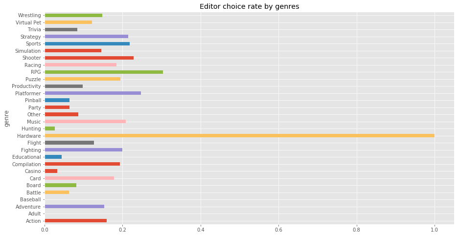

```python
plt.style.use('ggplot')
plt.figure(figsize=(15,8))
editor_choice_rate = df_impute2_group_genre.editors_choice.sum()/df_impute2_group_genre.editors_choice.count()
ax =editor_choice_rate.plot(kind='barh')
plt.title('Editor choice rate by genres')
```

We can see that hardware game has 100% rate, but there are only two games in hardware genre, so they can not be representative. Then RPG's rate is a bit higner than other's, so we can notify gaming companies make efforts on this area.

### 3.1.2 Editors choice rate by release year

```python
df_impute2_group_year=df_impute2.groupby(by='release_year')
print(df_impute2_group_year.release_year.sum()/df_impute2_group_year.editors_choice.count())
```

```
release_year
1996    1996.0
1997    1997.0
1998    1998.0
1999    1999.0
2000    2000.0
2001    2001.0
2002    2002.0
2003    2003.0
2004    2004.0
2005    2005.0
2006    2006.0
2007    2007.0
2008    2008.0
2009    2009.0
2010    2010.0
2011    2011.0
2012    2012.0
2013    2013.0
2014    2014.0
2015    2015.0
2016    2016.0
dtype: float64
```

```
Text(0.5,1,'Editor choice rate by release year')
```

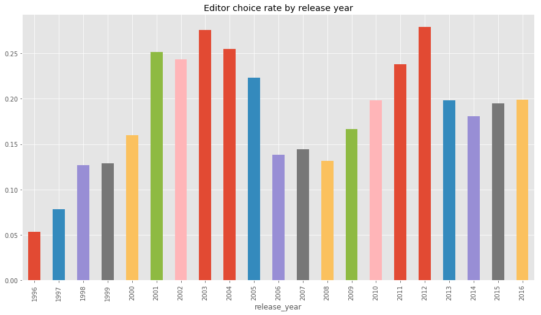

```python
editor_choice_rate = df_impute2_group_year.editors_choice.sum()/df_impute2_group_year.editors_choice.count()
plt.figure(figsize=(15,8))
ax =editor_choice_rate.plot(kind='bar')
plt.title('Editor choice rate by release year')
```

Here we can see that gaming industry went through two golden period: one is 2001-2005, the other is 2011-2012.

### 3.1.3 Editors choice rate by popular platform

```python
df_impute2_group_platform=df_impute2.groupby(by='platform')
meanofplt=18625/59
for val,grp in df_impute2_group_platform:
    if len(grp)>=meanofplt:
        print('There were',len(grp),'games in',val)

df_highplatform=df_impute2.loc[df_impute2['platform'].isin(['Game Boy Advance','Game Boy Color','GameCube','Nintendo DS','PC','PlayStation',
                                                  'PlayStation 2','PlayStation 3','PlayStation Portable','Wii','Wireless','Xbox',
                                                  'Xbox 360','iPhone'])]
df_platform=df_highplatform.groupby(by='platform')
```

```
There were 623 games in Game Boy Advance
There were 356 games in Game Boy Color
There were 509 games in GameCube
There were 1045 games in Nintendo DS
There were 3370 games in PC
There were 952 games in PlayStation
There were 1686 games in PlayStation 2
There were 1356 games in PlayStation 3
There were 633 games in PlayStation Portable
There were 1366 games in Wii
There were 910 games in Wireless
There were 821 games in Xbox
There were 1630 games in Xbox 360
There were 842 games in iPhone
```

```
editors_choice        False  True
platform
Game Boy Advance        524     99
Game Boy Color          324     32
GameCube                399    110
Nintendo DS             945    100
PC                     2691    679
PlayStation             828    124
PlayStation 2          1372    314
PlayStation 3          1014    342
PlayStation Portable    556     77
Wii                    1187    179
Wireless                642    268
Xbox                    609    212
Xbox 360               1264    366
iPhone                  690    152
```

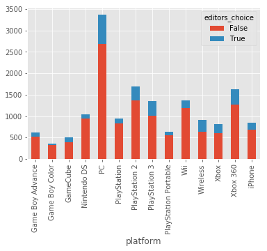

```python
whether_choice = pd.crosstab([df_highplatform['platform']], # categories to cross tabulate
                       df_highplatform.editors_choice.astype(bool)) # how to group
print(whether_choice)
whether_choice.plot(kind='bar', stacked=True)
```

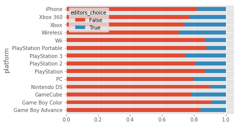

```python
choice_rate=whether_choice.div(whether_choice.sum(axis=1).astype(float),axis=0)

choice_rate.plot(kind='barh',stacked=True)
```

In this part, we noticed that the platform of Wireless, Xbox and playstation 3 had better rate, and this shows that the choice of platform is also a consideration for those gaming companies.

### 3.1.4 Distribution of scores

```
Text(0.5,1,'Distribution of score')
```

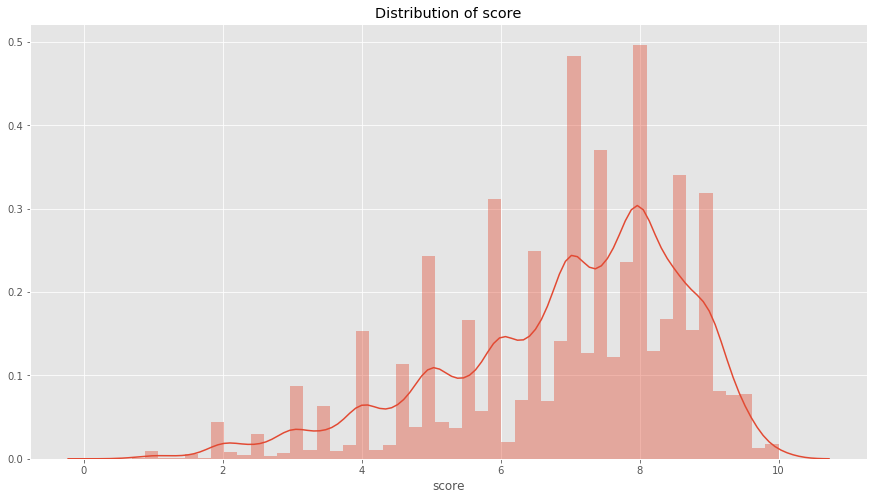

```python
import seaborn as sns
plt.figure(figsize=(15,8))
cmap = sns.diverging_palette(220, 10, as_cmap=True)

sns.distplot(df_impute2.score)
plt.title('Distribution of score')
```

The score of these games concentrate around eight points.

### 3.1.5 line chart of release and month

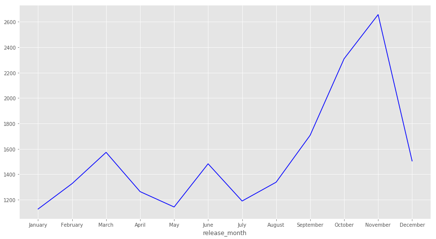

```python
plt.figure(figsize=(15,8))
plt.xticks(range(1,13),['January','February','March','April','May','June',
            'July','August','September','October','November','December'])
df_impute2.groupby(['release_month']).size().plot(c='b')
```

This trend is very specific and the most games were released in November.

## 3.2 Visualize relationships between a subset of attributes

### 3.2.1 Correaltion Matrix

```
Text(0.5,1,'Correlation Matrix Graph')
```

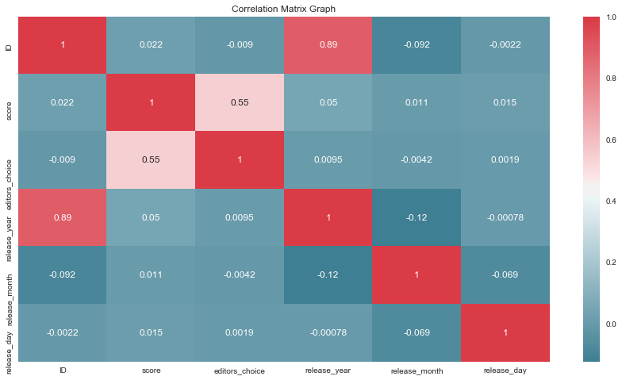

```python
# plot the correlation matrix using seaborn
sns.set(style="darkgrid") # one of the many styles to plot using

plt.figure(figsize=(15,8))

sns.heatmap(df_highplatform.corr(), cmap=cmap, annot=True)

plt.title('Correlation Matrix Graph')
```

We can see that score has strong relationship with editors' choice.

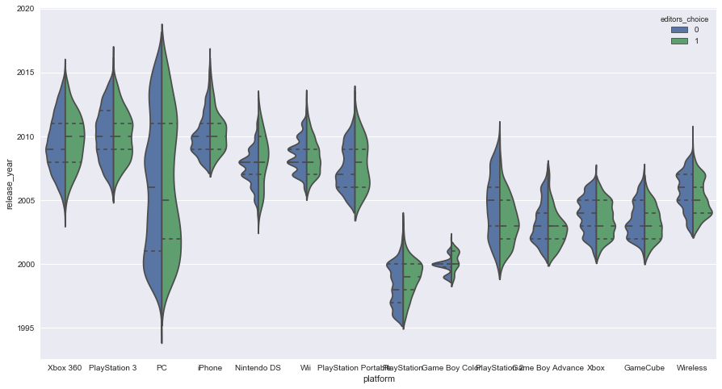

```python
plt.figure(figsize=(15,8))
sns.violinplot(x="platform", y="release_year", hue="editors_choice", data=df_highplatform,
               split=True, inner="quart")
```

In this pircture, we can see that PC platform has a longer history than others and some platforms only exist for several years only. PC platform has a stable development in gaming industry, so it is a good idea that make games in this area.

### 3.2.3 Average Editor choice rate by Top Genres by years

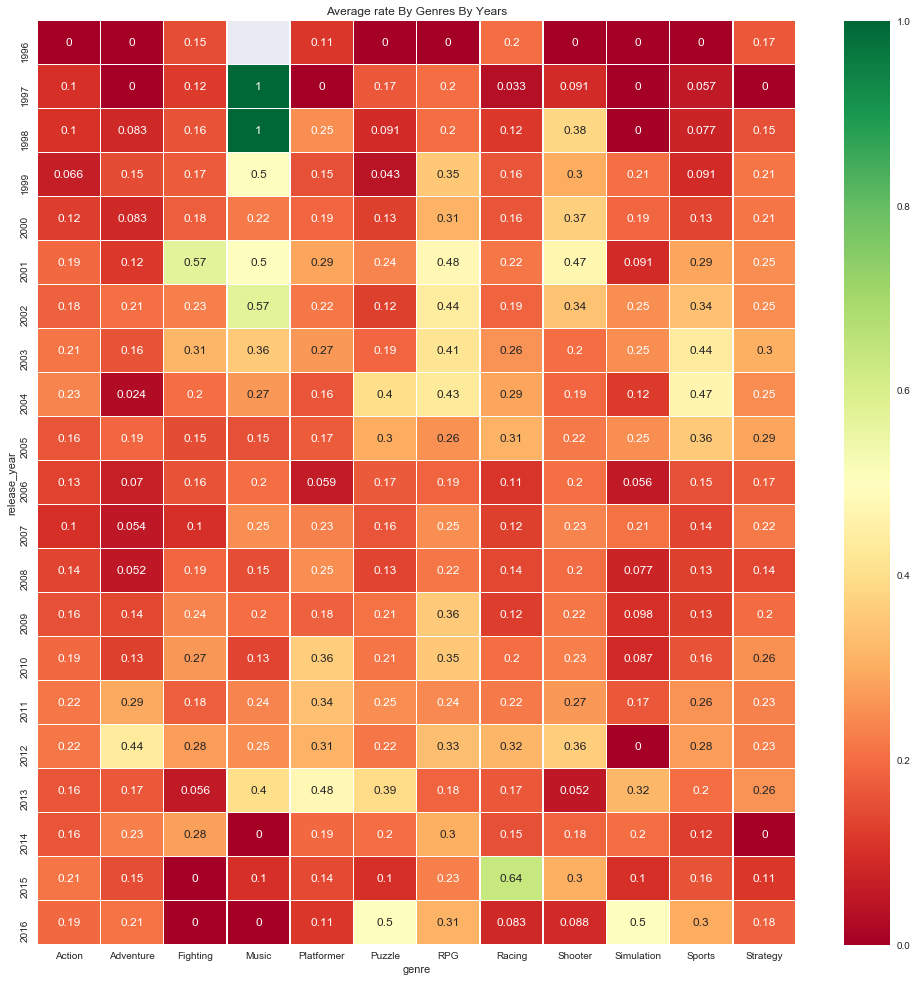

```python
plt.subplots(figsize=(17,17))
max_genres=df_impute2.groupby('genre')['genre'].count()
max_genres=max_genres[max_genres.values>200]
max_genres.sort_values(ascending=True,inplace=True)
mean_games=df_impute2[df_impute2['genre'].isin(max_genres.index)]
abc=mean_games.groupby(['release_year','genre'])['editors_choice'].mean().reset_index()
abc=abc.pivot('release_year','genre','editors_choice')
sns.heatmap(abc,annot=True,cmap='RdYlGn',linewidths=0.4)
plt.title('Average rate By Genres By Years')
plt.show()
```